# Titanic Project

Stephanie Oliva

December 5, 2015

The following details the creation of a logistic regression model to predict passenger survival after the devastating shipwreck of the RMS Titanic on April 15, 1912.

```r
train <- read.csv("/Users/Steph/Documents/STAT408/Titanic/train.csv")
train1 <- read.csv("/Users/Steph/Documents/STAT408/Titanic/train.csv", na.strings=c("NA", "NULL"))
test <- read.csv("/Users/Steph/Documents/STAT408/Titanic/test.csv", na.strings=c("NA", "NULL"))
```

**Data Summary**

```r
str(train1)
```

```
## 'data.frame':    891 obs. of  12 variables:
##  $ PassengerId: int  1 2 3 4 5 6 7 8 9 10 ...
##  $ Survived   : int  0 1 1 1 0 0 0 0 1 1 ...
##  $ Pclass     : int  3 1 3 1 3 3 1 3 3 2 ...
##  $ Name       : Factor w/ 891 levels "Abbing, Mr. Anthony",..: 109 191 358 277 16 559 520 629 417 581 ...
##  $ Sex        : Factor w/ 2 levels "female","male": 2 1 1 1 2 2 2 2 1 1 ...
##  $ Age        : num  22 38 26 35 35 NA 54 2 27 14 ...
##  $ SibSp      : int  1 1 0 1 0 0 0 3 0 1 ...
##  $ Parch      : int  0 0 0 0 0 0 0 1 2 0 ...
##  $ Ticket     : Factor w/ 681 levels "110152","110413",..: 524 597 670 50 473 276 86 396 345 133 ...
##  $ Fare       : num  7.25 71.28 7.92 53.1 8.05 ...
##  $ Cabin      : Factor w/ 148 levels "","A10","A14",..: 1 83 1 57 1 1 131 1 1 1 ...
##  $ Embarked   : Factor w/ 4 levels "","C","Q","S": 4 2 4 4 4 3 4 4 4 2 ...
```

```r
train1$Pclass <- as.factor(train1$Pclass)
```

The train1 dataset has 891 observations and 12 variables: PassengerId, Survived, Pclass (Passenger Class), Name, Sex, Age, SibSp (Sibling and Spousal relationships), Parch (Parent and Child relationships), Ticket number, Fare, Cabin, and Embarked. Note that Pclass is entered as an integer; it should be converted to a factor.

```r
summary(train1)
```

```
##   PassengerId       Survived      Pclass
##  Min.   :  1.0   Min.   :0.0000   1:216
##  1st Qu.:223.5   1st Qu.:0.0000   2:184
##  Median :446.0   Median :0.0000   3:491
##  Mean   :446.0   Mean   :0.3838
##  3rd Qu.:668.5   3rd Qu.:1.0000
##  Max.   :891.0   Max.   :1.0000
##
##                                     Name         Sex           Age
##  Abbing, Mr. Anthony                  :  1   female:314   Min.   : 0.42
##  Abbott, Mr. Rossmore Edward          :  1   male  :577   1st Qu.:20.12
##  Abbott, Mrs. Stanton (Rosa Hunt)     :  1                Median :28.00
##  Abelson, Mr. Samuel                  :  1                Mean   :29.70
##  Abelson, Mrs. Samuel (Hannah Wizosky):  1                3rd Qu.:38.00
##  Adahl, Mr. Mauritz Nils Martin       :  1                Max.   :80.00
##  (Other)                              :885                NA's   :177
##      SibSp           Parch             Ticket         Fare
##  Min.   :0.000   Min.   :0.0000   1601    :  7   Min.   :  0.00
##  1st Qu.:0.000   1st Qu.:0.0000   347082  :  7   1st Qu.:  7.91
##  Median :0.000   Median :0.0000   CA. 2343:  7   Median : 14.45
##  Mean   :0.523   Mean   :0.3816   3101295 :  6   Mean   : 32.20
##  3rd Qu.:1.000   3rd Qu.:0.0000   347088  :  6   3rd Qu.: 31.00
##  Max.   :8.000   Max.   :6.0000   CA 2144 :  6   Max.   :512.33
##                                   (Other) :852
##          Cabin     Embarked
##             :687    :  2
##  B96 B98    :  4   C:168
##  C23 C25 C27:  4   Q: 77
##  G6         :  4   S:644
##  C22 C26    :  3
##  D          :  3
##  (Other)    :186
```

Observations from the summary output:

**Survived:** skewed, clearly showing that the majority of passengers did not survive (0). **Pclass:** 3 levels (1, 2, 3), the majority being in 3rd class. **Name:** includes title and nicknames in addition to first and last names. **Age:** average age is late 20s, however there are 177 missing values. **Parch:** not very many Parent/Child relationships were documented. **Fare:** large range 0 to 512.33, right-skewed with a mean of 32.2. It is unclear why Fare would have a value of 0, this should be reviewed. **Cabin:** a large number of missing values. **Embarked:** uneven distribution of passengers embarking across the 3 ports.

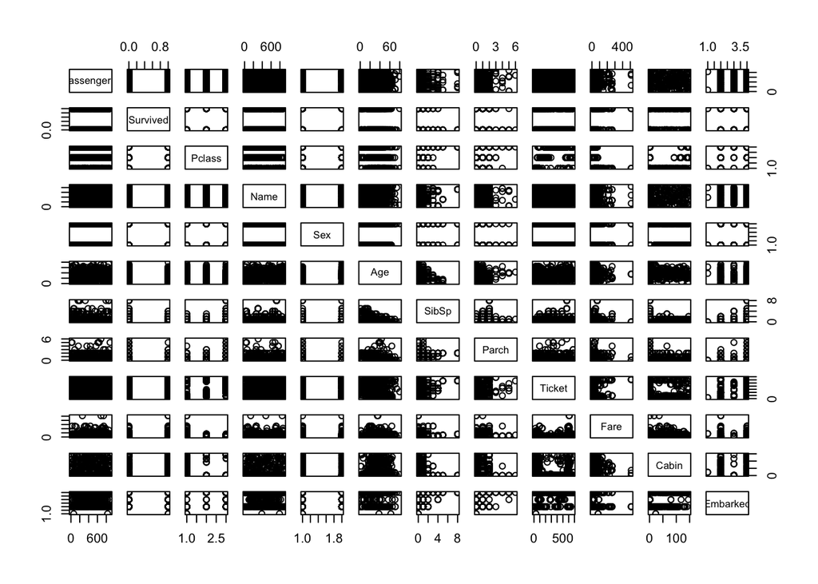

```r
plot(train1)
```

In logistic regression overlap among response and predictor variables is necessary to avoid complete or quasi-complete separation. This separation indicates that a predictor or set of predictors separates the observations almost entirely into 0 and 1. This should be avoided because while it sounds beneficial, it is unlikely to be representative of the greater population. From the scatter plot matrix, Cabin, Ticket, Name, and PassengerId appear to have a sufficient overlap regarding survival (0 and 1). These are also variables that will likely not be used. Given the amount of information presented in this matrix, an in-depth look at the other variables is required.

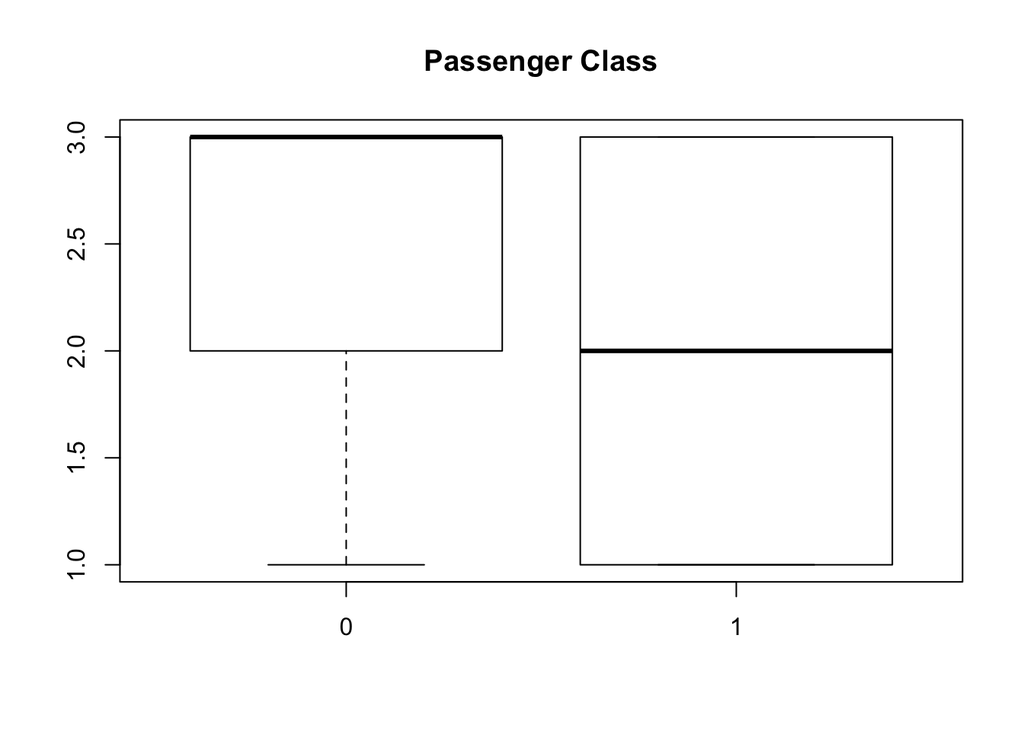

```r
boxplot(as.integer(Pclass)~Survived, data=train1, main="Passenger Class")
```

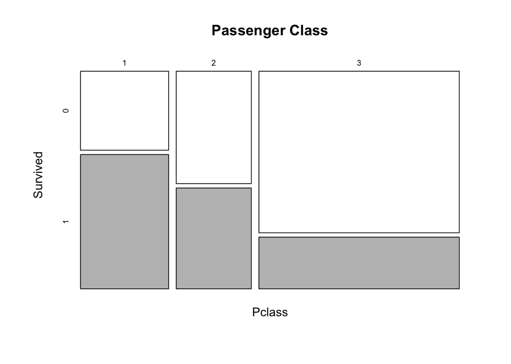

```r
mosaicplot(~Pclass + Survived, data=train1, main = "Passenger Class", color= c(0,8))
```

From the Pclass mosaic plot it can be determined that not surprisingly an overwhelming number of third class passengers did not survive, versus second and first class passengers.

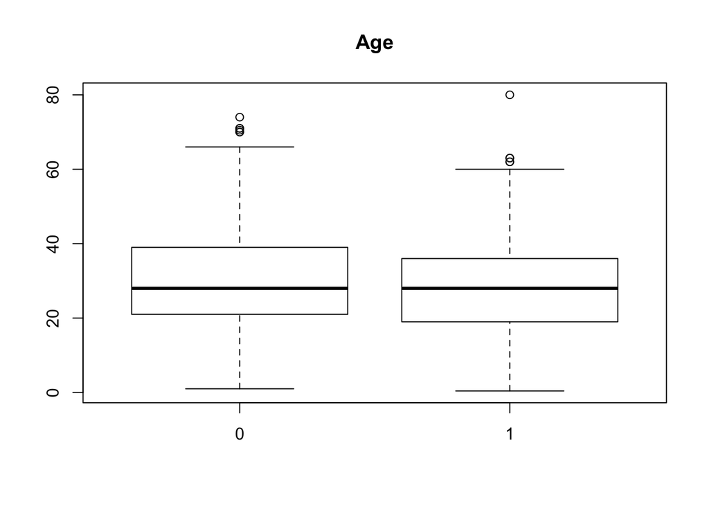

```r
boxplot(Age~Survived, data=train1, main="Age")
```

There is quite a lot of overlap between survival rates for passengers by age. Intrinsically, given the “women and children first” policy, it would seem that age, specifically a lower age would be seen in the survival plot, though that does not seem to be the case. This might be due to the large amount of missing age values present in the dataset.

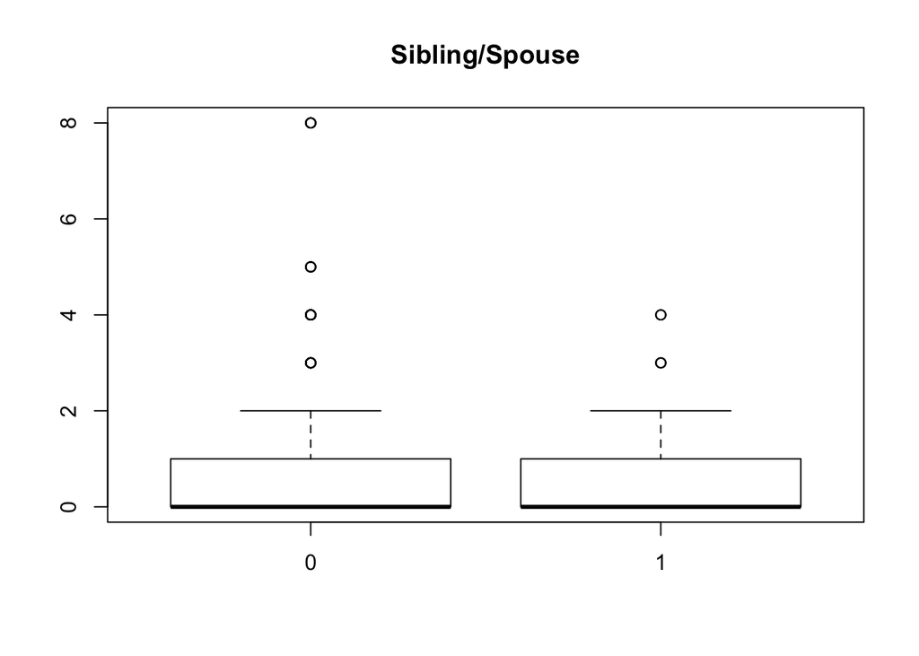

```r
boxplot(SibSp~Survived, data=train1, main="Sibling/Spouse")
```

The SibSp boxplot shows almost identical overlap.

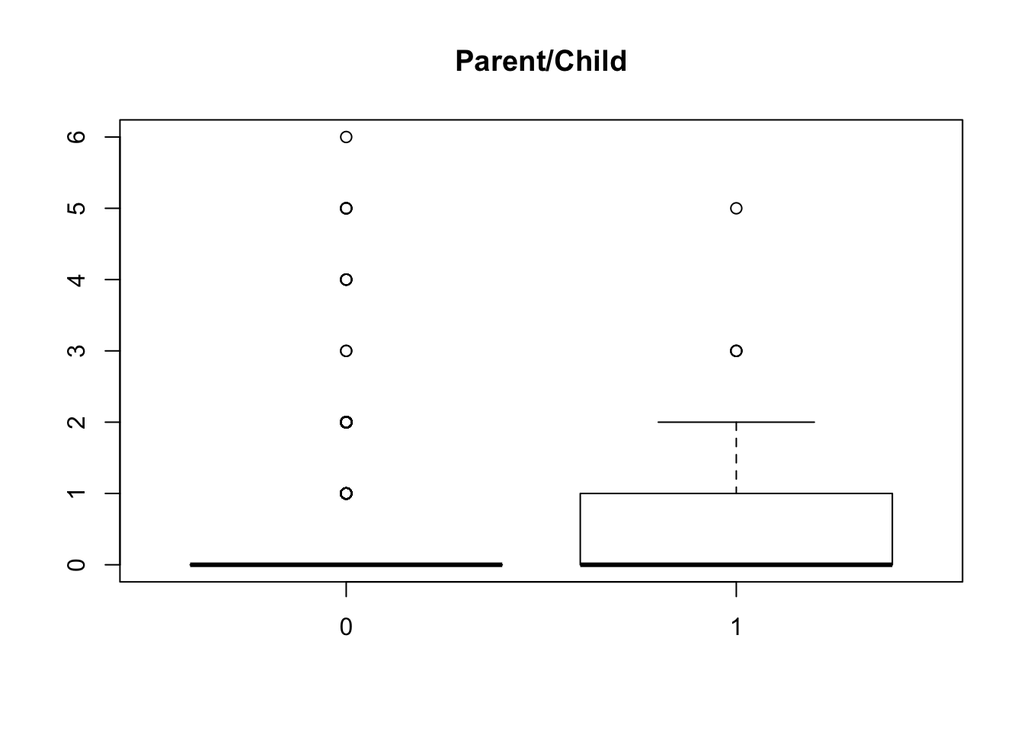

```r
boxplot(Parch~Survived, data=train1, main="Parent/Child")
```

From the outliers, it seems passengers with Parent/Child relationships greater than 1 were not as likely to survive.

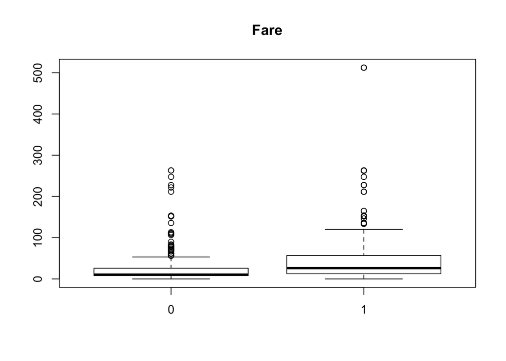

```r
boxplot(Fare~Survived, data=train1, main="Fare")
```

```r
summary(train1$Fare)
```

```
##    Min. 1st Qu.  Median    Mean 3rd Qu.    Max.
##    0.00    7.91   14.45   32.20   31.00  512.30
```

```r
subset(train1, Fare == 0)
```

```
##     PassengerId Survived Pclass                             Name  Sex Age
## 180         180        0      3              Leonard, Mr. Lionel male  36
## 264         264        0      1            Harrison, Mr. William male  40
## 272         272        1      3     Tornquist, Mr. William Henry male  25
## 278         278        0      2      Parkes, Mr. Francis "Frank" male  NA
## 303         303        0      3  Johnson, Mr. William Cahoone Jr male  19
## 414         414        0      2   Cunningham, Mr. Alfred Fleming male  NA
## 467         467        0      2            Campbell, Mr. William male  NA
## 482         482        0      2 Frost, Mr. Anthony Wood "Archie" male  NA
## 598         598        0      3              Johnson, Mr. Alfred male  49
## 634         634        0      1    Parr, Mr. William Henry Marsh male  NA
## 675         675        0      2       Watson, Mr. Ennis Hastings male  NA
## 733         733        0      2             Knight, Mr. Robert J male  NA
## 807         807        0      1           Andrews, Mr. Thomas Jr male  39
## 816         816        0      1                 Fry, Mr. Richard male  NA
```

[output cut: 17 more lines]

The outlier that paid over $500 in fare survived. There is overlap by fare type in the number of passengers that survived with those that did not. There are 15 such instances, from a variety of classes and ages, including a Jonkheer, which is a Dutch honorific of nobility. It is unlikely that these fares were not paid. Assuming they were not paid by other passengers, the fare could be populated using the average fare paid by class.

Proportion tables can be created to understand survival based on sex and embarkation.

```r
prop.table(table(train1$Sex, train1$Survived),1)
```

```
##
##                  0         1
##   female 0.2579618 0.7420382
##   male   0.8110919 0.1889081
```

A greater proportion of women survived compared to men, as expected.

```r
prop.table(table(train1$Embarked, train1$Survived),1)
```

```
##
##             0         1
##     0.0000000 1.0000000
##   C 0.4464286 0.5535714
##   Q 0.6103896 0.3896104
##   S 0.6630435 0.3369565
```

An almost even number of passengers that embarked at Cherbourg survived, whereas the majority of passengers that embarked at Queenstown and Southampton did not survive. This could be related to passenger class.

Given the overview above, a possible model could be created with Age, Pclass, Parch, Sex, and Embarked. While Name may not be helpful in its current state, the title could be extracted to determine if that would assist in identifying survivors, since first class passengers would have titles fitting their social status. If including Fare, mean values could be calculated to replace 0. Lastly, to include Age in the model, the missing values would have to be identified, possibly through the creation of a predictive linear regression model, using the other variables in the dataset.

**Manipulating Name**

```r
library(stringr)
train1$title <- str_sub(train1$Name, str_locate(train1$Name, ",")[ , 1] + 2, str_locate(train1$Name, "\\.")[ , 1] - 1)
table(train1$title)
```

```
##
##         Capt          Col          Don           Dr     Jonkheer
##            1            2            1            7            1
##         Lady        Major       Master         Miss         Mlle
##            1            2           40          182            2
##          Mme           Mr          Mrs           Ms          Rev
##            1          517          125            1            6
##          Sir the Countess
##            1            1
```

```r
prop.table(table(train1$title, train1$Survived),1)
```

```
##
##                        0         1
##   Capt         1.0000000 0.0000000
##   Col          0.5000000 0.5000000
##   Don          1.0000000 0.0000000
##   Dr           0.5714286 0.4285714
##   Jonkheer     1.0000000 0.0000000
##   Lady         0.0000000 1.0000000
##   Major        0.5000000 0.5000000
##   Master       0.4250000 0.5750000
##   Miss         0.3021978 0.6978022
##   Mlle         0.0000000 1.0000000
##   Mme          0.0000000 1.0000000
##   Mr           0.8433269 0.1566731
##   Mrs          0.2080000 0.7920000
##   Ms           0.0000000 1.0000000
##   Rev          1.0000000 0.0000000
##   Sir          0.0000000 1.0000000
##   the Countess 0.0000000 1.0000000
```

From the table above, there are 17 different titles. It appears a greater number of passengers with the title: Mrs, Ms, Miss, Master, Lady, Countess, Mme, and Mlle survived. Given the many levels, it would be beneficial to reclassify the variables, keeping nobility (i.e. titles indicating higher social status) together, and combining Miss and Ms.

```r
noble <- c("Capt", "Col", "Don", "Dr", "Jonkheer", "Major", "Rev", "Sir", "Lady", "Mlle", "Mme", "the Countess")
train1$title[train1$title %in% noble] <- "noble"
Ms<- c("Ms", "Miss")
train1$title[train1$title %in% Ms] <- "Miss"
train1$title <- as.factor(train1$title)
```

**Manipulating Fare**

In addition to reclassifying and creating the Title variable, zero fares could be replaced with the median values of fares by passenger class. The median would be used over the mean because it is a more robust measure, particularly considering this skewed dataset.

```r
summary(train1$Fare)
```

```
##    Min. 1st Qu.  Median    Mean 3rd Qu.    Max.
##    0.00    7.91   14.45   32.20   31.00  512.30
```

```r
aggregate(Fare~Pclass,train1,median)
```

```
##   Pclass    Fare
## 1      1 60.2875
## 2      2 14.2500
## 3      3  8.0500
```

```r
train1$Fare <- ifelse( (round(train1$Fare==0) & as.numeric(train1$Pclass)==1),60.2875,
                    ifelse( (round(train1$Fare==0) & as.numeric(train1$Pclass)==2),14.25,
                            ifelse( (round(train1$Fare==0) & as.numeric(train1$Pclass)==3),8.05,train1$Fare)))
summary(train1$Fare)
```

```
##    Min. 1st Qu.  Median    Mean 3rd Qu.    Max.
##   4.012   7.925  14.500  32.670  31.280 512.300
```

**Predicting Age**

Since it appears appropriate to include age in the model, a method must be devised to predict the age values. There are multiple ways to do this, including creating a prediction model, imputing values, or assigning the mean value of age (29.7) to all the missing values. In this project, a prediction linear regression model will be created.

The First step is to create a dataset with all the known age values.

```r
knownAge <- train1[which(train1$Age != ""),]
```

Next, a model can be fit with each of the predictors against Age, to see which variables are significant. Ticket and Name will not be included, given the many levels in these variables. Survived will also not be included because it is not a variable in the test dataset. PassengerId will also be excluded given its arbitrary nature. Since this is a prediction linear regression model, outliers, leverage, and influence will be overlooked. *For brevity, summaries will be commented out.*

```r
Pclass <- lm(Age ~ Pclass, data=knownAge)
#summary(Pclass)

Sex <- lm(Age ~ Sex, data=knownAge)
#summary(Sex)

Fare <- lm(Age ~ Fare, data=knownAge)
#summary(Fare)

Sibsp <- lm(Age ~ SibSp, data=knownAge)
#summary(Sibsp)

Parch <- lm(Age ~ Parch, data=knownAge)
#summary(Parch)

Title <- lm(Age ~ title, data=knownAge)
#summary(Title)
```

The following variables are identified as significant at alpha=0.05: Pclass, Sex, SibSp, Parch, Fare, and Title.

Models will be assessed based on AIC score. While coefficient estimates are not terribly important in prediction modeling, it may still be helpful to note.

```r
Age1 <- lm(Age ~ Pclass + Sex + Fare + SibSp + Parch + title, data=knownAge)
#summary(Age1)
AIC(Age1)
```

```
## [1] 5485.148
```

The coefficient estimates for Parch and Fare are not significant at alpha=0.05.

```r
Age2 <- lm(Age ~ Pclass + SibSp + title + Sex + Fare, data=knownAge)
#summary(Age2)
AIC(Age2)
```

```
## [1] 5483.598
```

All predictor estimates are significant at alpha=0.05.

Perhaps since title and sex indicate the similar information, one or the other could be removed.

```r
Age3 <- lm(Age ~ Pclass + SibSp + Fare + Sex, data=knownAge)
#summary(Age3)
AIC(Age3)
```

```
## [1] 5663.111
```

All parameter estimates are significant at alpha=0.05. Given the increases AIC, title should be in the model.

```r
Age4 <- lm(Age ~ Pclass + SibSp + Fare+ title, data=knownAge)
#summary(Age4)
AIC(Age4)
```

```
## [1] 5491.407
```

AIC increases without Sex in the model. Fare is not significant at alpha=0.05. It would also be beneficial to remove other variables to determine their effect.

```r
Age5 <- lm(Age ~ SibSp + title + Sex + Fare, data=knownAge)
#summary(Age5)
AIC(Age5)
```

```
## [1] 5574.557
```

Without Pclass, all predictor estimates are significant at alpha=0.05.

```r
Age6 <- lm(Age ~ Pclass + title + Sex + Fare, data=knownAge)
#summary(Age6)
AIC(Age6)
```

```
## [1] 5496.907
```

Without SibSp, all predictor estimates are significant at alpha=0.01.

```r
Age7 <- lm(Age ~ Pclass + SibSp + title + Sex, data=knownAge)
#summary(Age7)
AIC(Age7)
```

```
## [1] 5485.593
```

Without Fare, all predictor estimates are significant at alpha=0.01.

The lowest AIC score belongs to model Age2. Transformations and Interactions could be attempted. Possible transformations can be done on SibSp as it is the only count/integer variable. *For brevity, summary calls will be commented out.*

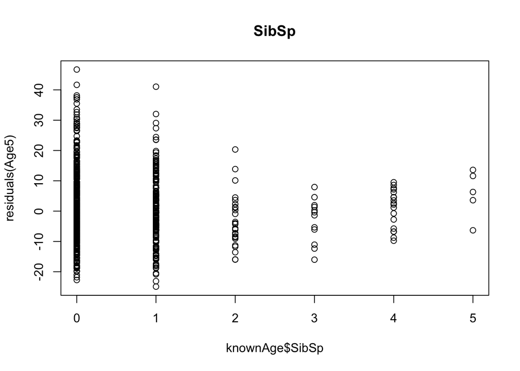

```r
plot(knownAge$SibSp, residuals(Age5), main="SibSp")
```

```r
Age8 <- lm(Age ~ Pclass + Sex + I(SibSp^2) + SibSp + title + Fare, data=knownAge)
#summary(Age8)
AIC(Age8)
```

```
## [1] 5480.981
```

When squaring SibSp values, all predictor estimates are significant at alpha=0.05, with the exception of Fare.

```r
Age9 <- lm(Age ~ Pclass + Sex + I(sqrt(SibSp)) + SibSp + title + Fare,  data=knownAge)
#summary(Age9)
AIC(Age9)
```

```
## [1] 5482.271
```

When taking the square root of SibSp values, all predictor estimates are significant at alpha=0.05, with the exception of SibSp and its transformation.

Interactions could also be reviewed.

```r
Age10 <- lm(Age ~ Pclass + Fare + Sex + SibSp*title, data=knownAge)
#summary(Age10)
AIC(Age10)
```

```
## [1] 5474.085
```

```r
Age11 <- lm(Age ~ Pclass*title + Sex + SibSp + Fare, data=knownAge)
#summary(Age11)
AIC(Age11)
```

```
## [1] 5482.723
```

```r
Age12 <- lm(Age ~ Pclass + SibSp + Fare + title*Sex, data=knownAge)
#summary(Age12)
AIC(Age12)
```

```
## [1] 5483.598
```

```r
Age13 <- lm(Age ~ Pclass*Sex + SibSp + title + Fare, data=knownAge)
#summary(Age13)
AIC(Age13)
```

```
## [1] 5487.539
```

```r
Age14 <- lm(Age ~ Pclass*title + Sex + SibSp*title + Fare, data=knownAge)
#summary(Age14)
AIC(Age14)
```

```
## [1] 5480.645
```

```r
Age15 <-lm(Age ~ Pclass + Sex + SibSp + title*Fare, data=knownAge)
#summary(Age15)
AIC(Age15)
```

```
## [1] 5488.992
```

```r
Age16 <-lm(Age ~ Pclass + Sex*Fare + SibSp + title, data=knownAge)
#summary(Age16)
AIC(Age16)
```

```
## [1] 5485.408
```

```r
Age17 <-lm(Age ~ Pclass*Fare + Sex + SibSp + title, data=knownAge)
#summary(Age17)
AIC(Age17)
```

```
## [1] 5482.566
```

```r
Age18 <-lm(Age ~ Pclass + Sex + SibSp*Fare + title, data=knownAge)
#summary(Age18)
AIC(Age18)
```

```
## [1] 5485.226
```

Combining interactions and transformations:

```r
Age19 <- lm(Age ~ Pclass*title + Sex + I(SibSp^2) + SibSp*title + Fare, data=knownAge)
#summary(Age19)
AIC(Age19)
```

```
## [1] 5481.83
```

The age prediction model that has the lowest AIC score is model Age10, which includes variables: Pclass, Sex, SibSp, title, Fare and an interaction with SibSp and title.

Cross validation will now be used with model Age10 to determine how similar the predictions are to the summary of the known age values.

```r
knownAge$pred<-rep(NA, 714)
for (i in 1:dim(knownAge)[1]){
  a<-lm(Age ~Pclass + Fare + Sex + SibSp * title,knownAge[-i,])
  knownAge$pred[i]<-predict(a,knownAge[i,],type="response")
}
summary(knownAge$Age)
```

```
##    Min. 1st Qu.  Median    Mean 3rd Qu.    Max.
##    0.42   20.12   28.00   29.70   38.00   80.00
```

```r
summary(knownAge$pred)
```

```
##    Min. 1st Qu.  Median    Mean 3rd Qu.    Max.
## -0.9784 27.1600 29.8500 29.7000 33.5400 62.5800
```

The summary indicates that the predicted age values are close to the mean and median of the known ages. However, the negative values must be reviewed.

```r
length(which(knownAge$pred <= 0))
```

```
## [1] 3
```

3 negative values.

While I will use the model Age10 to predict Age, any resulting negative values will be converted to 0. The predicted values can now be included in the train1 dataset.

```r
for(i in 1:nrow(train1))
{
  if(is.na(train1[i,"Age"]))
  {
    train1[i,"Age"] <- predict(Age10, newdata=train1[i,])
  }

}
summary(train1$Age)
```

```
##    Min. 1st Qu.  Median    Mean 3rd Qu.    Max.
##  -7.994  21.000  29.710  29.410  36.750  80.000
```

```r
summary(train$Age)
```

```
##    Min. 1st Qu.  Median    Mean 3rd Qu.    Max.    NA's
##    0.42   20.12   28.00   29.70   38.00   80.00     177
```

```r
length(which(train1$Age <= 0))
```

```
## [1] 3
```

Since Age cannot be negative, such values will be converted 0.

```r
train1$Age[train1$Age < 0] <- 0
summary(train1$Age)
```

```
##    Min. 1st Qu.  Median    Mean 3rd Qu.    Max.
##    0.00   21.00   29.71   29.44   36.75   80.00
```

**Logistic Regression**

With the missing Age values now predicted, logistic regression for survival prediction can begin. The first step is to determine which variables would be considered significant, compared to an intercept-only model.

```r
null_mod <- glm (Survived ~ 1, data= train1, family = binomial())
Pclass <- glm (Survived ~ Pclass, data= train1, family = binomial())
anova(null_mod, Pclass, test ="LRT")
```

```
## Analysis of Deviance Table
##
## Model 1: Survived ~ 1
## Model 2: Survived ~ Pclass
##   Resid. Df Resid. Dev Df Deviance  Pr(>Chi)
## 1       890     1186.7
## 2       888     1083.1  2   103.55 < 2.2e-16 ***
## ---
## Signif. codes:  0 '***' 0.001 '**' 0.01 '*' 0.05 '.' 0.1 ' ' 1
```

```r
Title <- glm (Survived ~ title, data= train1, family = binomial())
anova(null_mod, Title, test ="LRT")
```

```
## Analysis of Deviance Table
##
## Model 1: Survived ~ 1
## Model 2: Survived ~ title
##   Resid. Df Resid. Dev Df Deviance  Pr(>Chi)
## 1       890    1186.66
## 2       886     890.41  4   296.24 < 2.2e-16 ***
## ---
## Signif. codes:  0 '***' 0.001 '**' 0.01 '*' 0.05 '.' 0.1 ' ' 1
```

```r
Sex <- glm (Survived ~ Sex, data= train1, family = binomial())
anova(null_mod, Sex, test ="LRT")
```

```
## Analysis of Deviance Table
##
## Model 1: Survived ~ 1
## Model 2: Survived ~ Sex
##   Resid. Df Resid. Dev Df Deviance  Pr(>Chi)
## 1       890     1186.7
## 2       889      917.8  1   268.85 < 2.2e-16 ***
## ---
## Signif. codes:  0 '***' 0.001 '**' 0.01 '*' 0.05 '.' 0.1 ' ' 1
```

```r
Age <- glm (Survived ~ Age, data= train1, family = binomial())
anova(null_mod, Age, test ="LRT")
```

```
## Analysis of Deviance Table
##
## Model 1: Survived ~ 1
## Model 2: Survived ~ Age
##   Resid. Df Resid. Dev Df Deviance Pr(>Chi)
## 1       890     1186.7
## 2       889     1182.5  1    4.119   0.0424 *
## ---
## Signif. codes:  0 '***' 0.001 '**' 0.01 '*' 0.05 '.' 0.1 ' ' 1
```

```r
SibSp <- glm (Survived ~ SibSp, data= train1, family = binomial())
anova(null_mod, SibSp, test ="LRT")
```

```
## Analysis of Deviance Table
##
## Model 1: Survived ~ 1
## Model 2: Survived ~ SibSp
##   Resid. Df Resid. Dev Df Deviance Pr(>Chi)
## 1       890     1186.7
## 2       889     1185.5  1   1.1404   0.2856
```

```r
Parch <- glm (Survived ~ Parch, data= train1, family = binomial())
anova(null_mod, Parch, test ="LRT")
```

```
## Analysis of Deviance Table
##
## Model 1: Survived ~ 1
## Model 2: Survived ~ Parch
##   Resid. Df Resid. Dev Df Deviance Pr(>Chi)
## 1       890     1186.7
## 2       889     1180.8  1   5.8135   0.0159 *
## ---
## Signif. codes:  0 '***' 0.001 '**' 0.01 '*' 0.05 '.' 0.1 ' ' 1
```

```r
Ticket <- glm (Survived ~ Ticket, data= train1, family = binomial())
anova(null_mod, Ticket, test ="LRT")
```

```
## Analysis of Deviance Table
##
## Model 1: Survived ~ 1
## Model 2: Survived ~ Ticket
##   Resid. Df Resid. Dev  Df Deviance  Pr(>Chi)
## 1       890    1186.66
## 2       210     166.47 680   1020.2 4.527e-16 ***
## ---
## Signif. codes:  0 '***' 0.001 '**' 0.01 '*' 0.05 '.' 0.1 ' ' 1
```

```r
Fare <- glm (Survived ~ Fare, data= train1, family = binomial())
anova(null_mod, Fare, test ="LRT")
```

```
## Analysis of Deviance Table
##
## Model 1: Survived ~ 1
## Model 2: Survived ~ Fare
##   Resid. Df Resid. Dev Df Deviance  Pr(>Chi)
## 1       890     1186.7
## 2       889     1121.8  1   64.847 8.096e-16 ***
## ---
## Signif. codes:  0 '***' 0.001 '**' 0.01 '*' 0.05 '.' 0.1 ' ' 1
```

```r
Cabin <- glm (Survived ~ Cabin, data= train1, family = binomial())
anova(null_mod, Cabin, test ="LRT")
```

```
## Analysis of Deviance Table
##
## Model 1: Survived ~ 1
## Model 2: Survived ~ Cabin
##   Resid. Df Resid. Dev  Df Deviance  Pr(>Chi)
## 1       890     1186.7
## 2       743      892.2 147   294.45 6.469e-12 ***
## ---
## Signif. codes:  0 '***' 0.001 '**' 0.01 '*' 0.05 '.' 0.1 ' ' 1
```

```r
Embarked <- glm (Survived ~ Embarked, data= train1, family = binomial())
anova(null_mod, Embarked, test ="LRT")
```

```
## Analysis of Deviance Table
##
## Model 1: Survived ~ 1
## Model 2: Survived ~ Embarked
##   Resid. Df Resid. Dev Df Deviance  Pr(>Chi)
## 1       890     1186.7
## 2       887     1157.0  3   29.703 1.594e-06 ***
## ---
## Signif. codes:  0 '***' 0.001 '**' 0.01 '*' 0.05 '.' 0.1 ' ' 1
```

The Likelihood Ratio Test performed above indicate that the following variables are significant: Pclass, title, Sex, Age, Parch, Ticket, Fare, Cabin, and Embarked. The next step is to fit a logistic regression model with these predictors. Models will be assessed based on AIC score.

```r
lr1 <-glm(Survived ~ Pclass + title + Sex + Age + Parch + Ticket + Fare + Cabin + Embarked, data= train1, family = binomial())
```

```
## Warning: glm.fit: fitted probabilities numerically 0 or 1 occurred
```

This model yielded an error of complete or quasi-complete separation. Since Cabin has a large number of missing values, it could be removed from the model.

```r
lr2 <-glm(Survived ~ Pclass + title + Sex + Age + Parch + Ticket + Fare + Embarked, data= train1, family = binomial())
```

```
## Warning: glm.fit: fitted probabilities numerically 0 or 1 occurred
```

Again, there is a similar warning. I would argue that Ticket should be removed given that this variable has a large number of levels, with little meaning.

```r
lr3 <-glm(Survived ~ Pclass + title + Sex + Age + Parch + Fare + Embarked, data= train1, family = binomial())
#summary(lr3)
```

AIC: 776.15

While SibSp was not considered significant when compared to the null model, it is possible that an interaction could be occurring with Parch, as that would indicate family size.

```r
lr4 <-glm(Survived ~ Pclass + title + Fare + Sex + Age + Parch*SibSp + Embarked, data= train1, family = binomial())
#summary(lr4)
```

AIC:753.7. There is a significant interaction with Parch and SibSp.

An interaction could also be attempted with Fare, perhaps with passenger class.

```r
lr5 <-glm(Survived ~ Pclass*Fare + title + Sex + Age + Parch*SibSp +  Embarked, data= train1, family = binomial())
#summary(lr5)
```

AIC: 755.71

Another interaction that could be attempted is Sex and Pclass.

```r
lr6 <-glm(Survived ~ Pclass*Sex + title + Age + Parch*SibSp + Fare + Embarked, data= train1, family = binomial())
#summary(lr6)
```

AIC: 735.78

Perhaps there is an interaction with title and Embarked.

```r
lr7 <- glm(Survived ~ Pclass*Sex + title*Embarked + Age + Parch*SibSp + Fare, data= train1, family = binomial())
#summary(lr7)
```

AIC: 740.36

Another possibility is interacting Age and Sex.

```r
lr8 <- glm(Survived ~ Pclass*Sex + title + Embarked + Age*Sex + Fare +  Parch*SibSp, data= train1, family = binomial())
#summary(lr8)
```

AIC: 735.66

Perhaps attempting an interaction with title and Sex.

```r
lr9 <- glm(Survived ~ Pclass*Sex + title*Sex + Embarked + Age*Sex + Parch*SibSp + Fare, data= train1, family = binomial())
#summary(lr9)
```

AIC: 735.66. That showed no improvement

Perhaps removing Embarked would help.

```r
lr10 <- glm(Survived ~ Pclass*Sex + title + Age*Sex + Parch*SibSp + Fare, data= train1, family = binomial())
#summary(lr10)
```

AIC: 732.85

Attempting an interaction with Fare and title.

```r
lr11 <- glm(Survived ~ Pclass*Sex + title*Fare + Age*Sex + Parch*SibSp, data= train1, family = binomial())
#summary(lr11)
```

AIC: 738.11. This also does not improve AIC. Perhaps interacting with Age and Sex.

```r
lr12 <- glm(Survived ~ Pclass*Sex + title + Age*Sex*Fare + Parch*SibSp, data= train1, family = binomial())
#summary(lr12)
```

AIC: 727.59

The models with the lowest AIC scores are: lr12 and lr10.

Cross validation and logloss with model lr12.

```r
train1$pred <- rep(NA, 891)
for (i in 1:891){
  a<-glm(Survived ~ Pclass*Sex + title + Age*Sex*Fare + Parch*SibSp, data= train1[-1], family = binomial())
  train1$pred[i]<-predict(a,train1[i,],type="response")
}

sum(-(train1$Survived * log(train1$pred) + (1-train1$Survived) * log(1-train1$pred)))
```

```
## [1] 344.7973
```

Logloss:344.7973

Since transformations helped to reduce AIC in the Age model, perhaps that could be attempted again. The only integer variables in the model are SibSp and Parch.

```r
lr13 <- glm(Survived ~ Pclass*Sex + title + Age*Sex*Fare + Parch*SibSp + I(Parch^2), data= train1, family = binomial())
#summary(lr13)
```

AIC: 729.53

```r
lr14 <- glm(Survived ~ Pclass*Sex + title + Age*Sex*Fare + Parch*SibSp + I(SibSp^2), data= train1, family = binomial())
#summary(lr14)
```

AIC: 725.19

Squaring SibSp yielded a lower AIC score, thus this model will be used in the following cross validation process.

```r
train1$pred <- rep(NA, 891)
for (i in 1:891){
  a<-glm(Survived ~ Pclass*Sex + title + Age*Sex*Fare + Parch*SibSp + I(SibSp^2), data= train1[-1], family = binomial())
  train1$pred[i]<-predict(a,train1[i,],type="response")
}

sum(-(train1$Survived * log(train1$pred) + (1-train1$Survived) * log(1-train1$pred)))
```

```
## [1] 342.5975
```

With a logloss value of 342.5975, the Titanic survival prediction model I present is:
$$\hat{y_{i}} = \hat{\beta_{0}} + \hat{\beta_{1}}SibSp + \hat{\beta_{2}}Sex + \hat{\beta_{3}}Fare + \hat{\beta_{4}}Age + \hat{\beta_{5}}title + \hat{\beta_{6}}Parch + \hat{\beta_{7}}(Pclass)(Sex) + \hat{\beta_{8}}(Age)(Sex)(Fare) + \hat{\beta_{9}}Parch(SibSp) + \hat{\beta_{10}}SibSp^2$$
*yi(hat) represents the survival predictions.*

**Prepare Test Dataset**

Finally, the test dataset has to be reclassified to reflect the training set.

```r
str(test)
```

```
## 'data.frame':    418 obs. of  11 variables:
##  $ PassengerId: int  892 893 894 895 896 897 898 899 900 901 ...
##  $ Pclass     : int  3 3 2 3 3 3 3 2 3 3 ...
##  $ Name       : Factor w/ 418 levels "Abbott, Master. Eugene Joseph",..: 210 409 273 414 182 370 85 58 5 104 ...
##  $ Sex        : Factor w/ 2 levels "female","male": 2 1 2 2 1 2 1 2 1 2 ...
##  $ Age        : num  34.5 47 62 27 22 14 30 26 18 21 ...
##  $ SibSp      : int  0 1 0 0 1 0 0 1 0 2 ...
##  $ Parch      : int  0 0 0 0 1 0 0 1 0 0 ...
##  $ Ticket     : Factor w/ 363 levels "110469","110489",..: 153 222 74 148 139 262 159 85 101 270 ...
##  $ Fare       : num  7.83 7 9.69 8.66 12.29 ...
##  $ Cabin      : Factor w/ 77 levels "","A11","A18",..: 1 1 1 1 1 1 1 1 1 1 ...
##  $ Embarked   : Factor w/ 3 levels "C","Q","S": 2 3 2 3 3 3 2 3 1 3 ...
```

```r
summary(test)
```

```
##   PassengerId         Pclass
##  Min.   : 892.0   Min.   :1.000
##  1st Qu.: 996.2   1st Qu.:1.000
##  Median :1100.5   Median :3.000
##  Mean   :1100.5   Mean   :2.266
##  3rd Qu.:1204.8   3rd Qu.:3.000
##  Max.   :1309.0   Max.   :3.000
##
##                                         Name         Sex
##  Abbott, Master. Eugene Joseph            :  1   female:152
##  Abelseth, Miss. Karen Marie              :  1   male  :266
##  Abelseth, Mr. Olaus Jorgensen            :  1
##  Abrahamsson, Mr. Abraham August Johannes :  1
##  Abrahim, Mrs. Joseph (Sophie Halaut Easu):  1
##  Aks, Master. Philip Frank                :  1
##  (Other)                                  :412
##       Age            SibSp            Parch             Ticket
##  Min.   : 0.17   Min.   :0.0000   Min.   :0.0000   PC 17608:  5
##  1st Qu.:21.00   1st Qu.:0.0000   1st Qu.:0.0000   113503  :  4
##  Median :27.00   Median :0.0000   Median :0.0000   CA. 2343:  4
##  Mean   :30.27   Mean   :0.4474   Mean   :0.3923   16966   :  3
##  3rd Qu.:39.00   3rd Qu.:1.0000   3rd Qu.:0.0000   220845  :  3
##  Max.   :76.00   Max.   :8.0000   Max.   :9.0000   347077  :  3
##  NA's   :86                                        (Other) :396
##       Fare                     Cabin     Embarked
##  Min.   :  0.000                  :327   C:102
##  1st Qu.:  7.896   B57 B59 B63 B66:  3   Q: 46
##  Median : 14.454   A34            :  2   S:270
##  Mean   : 35.627   B45            :  2
##  3rd Qu.: 31.500   C101           :  2
##  Max.   :512.329   C116           :  2
##  NA's   :1         (Other)        : 80
```

Set Pclass as factor:

```r
test$Pclass <- as.factor(test$Pclass)
```

Creating Title:

```r
test$title <- str_sub(test$Name, str_locate(test$Name, ",")[ , 1] + 2, str_locate(test$Name, "\\.")[ , 1] - 1)
table(test$title)
```

```
##
##    Col   Dona     Dr Master   Miss     Mr    Mrs     Ms    Rev
##      2      1      1     21     78    240     72      1      2
```

```r
noble <- c("Capt", "Col", "Don","Dona", "Dr", "Jonkheer", "Major", "Rev", "Sir", "Lady", "Mlle", "Mme", "the Countess")
test$title[test$title %in% noble] <- "noble"
Ms<- c("Ms", "Miss")
test$title[test$title %in% Ms] <- "Miss"
test$title <- as.factor(test$title)
```

Replacing 0 and NA Fare values with median based on passenger class.

```r
summary(test$Fare)
```

```
##    Min. 1st Qu.  Median    Mean 3rd Qu.    Max.    NA's
##   0.000   7.896  14.450  35.630  31.500 512.300       1
```

```r
aggregate(Fare~Pclass,test,median)
```

```
##   Pclass    Fare
## 1      1 60.0000
## 2      2 15.7500
## 3      3  7.8958
```

```r
test$Fare <- ifelse( (round(test$Fare==0) & as.numeric(test$Pclass)==1),60,
                    ifelse( (round(test$Fare==0) & as.numeric(test$Pclass)==2),15.75,
                            ifelse( (round(test$Fare==0) & as.numeric(test$Pclass)==3),7.8958,test$Fare)))
subset(test, is.na(test$Fare))
```

```
##     PassengerId Pclass               Name  Sex  Age SibSp Parch Ticket
## 153        1044      3 Storey, Mr. Thomas male 60.5     0     0   3701
##     Fare Cabin Embarked title
## 153   NA              S    Mr
```

```r
test$Fare <- ifelse(is.na(test$Fare), 7.8958, test$Fare)
summary(test$Fare)
```

```
##    Min. 1st Qu.  Median    Mean 3rd Qu.    Max.
##   3.171   7.896  14.460  35.850  31.500 512.300
```

Predicting Age:

```r
testAge <- lm(Age ~ Pclass + Fare + Sex + SibSp*title, data=test)
summary(test$Age)
```

```
##    Min. 1st Qu.  Median    Mean 3rd Qu.    Max.    NA's
##    0.17   21.00   27.00   30.27   39.00   76.00      86
```

```r
for(i in 1:nrow(test))
{
  if(is.na(test[i,"Age"]))
  {
    test[i,"Age"] <- predict(testAge, newdata=test[i,])
  }

}
summary(test$Age)
```

```
##    Min. 1st Qu.  Median    Mean 3rd Qu.    Max.
##    0.17   21.25   27.64   29.57   36.38   76.00
```

With that complete, the final step is to load the predicted Survived column to the test dataset.

```r
test$Survived <- 0

final_model <- glm(Survived ~ Pclass*Sex + title + Age*Sex*Fare + Parch*SibSp + I(SibSp^2), data=train1, family = binomial())

test$Survived <- predict(final_model, newdata=test, type="response")
test$Survived[test$Survived > 0.5] <-1
test$Survived[test$Survived !=1] <- 0
```

Submission to Kaggle

```r
submit <- data.frame(PassengerId = test$PassengerId, Survived = test$Survived)
write.csv(submit, file = "TitanicDec2015.csv", row.names = FALSE)
```

Kaggle score of 0.789

[output not shown]